# Part II - Loan DataSet from Prosper Analysis

## by PHILIP MWEMA

## Dataset Overview

> This data set contains 113,937 loans with 81 variables on each loan, including loan amount, borrower rate (or interest rate), current loan status, borrower income, and many others. I used some and not all of the set variables i.e loan status, term, etc

## Distribution of Loanees per term

> **Observation:** There are three types of loan terms provided by Prosper Loans, namely, 12 months, 36 months and 60 months. From the visualization below mid term loans of 36 months are most preffered by loanees, followed by long term loans of 60 months and lastly short term loans are the least preffered by loanees.

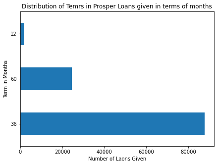

## NUMBER OF LOANS PER YEAR

> From the presentaions below, 2013 leads in the number of loans given out in a year, followed by 2012 while 2005 and 2009 have the least number of loans given out in a particular year.

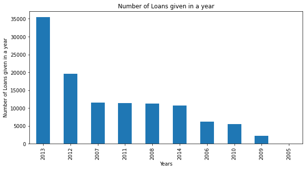

## Average Income per Household for each Term and Loan Status

> **Observation**: From the heat map we can draw coclusion that Individuals with higher incomes took short term loans and are more likely for late payments of past due, mostly 1 - 15 days.

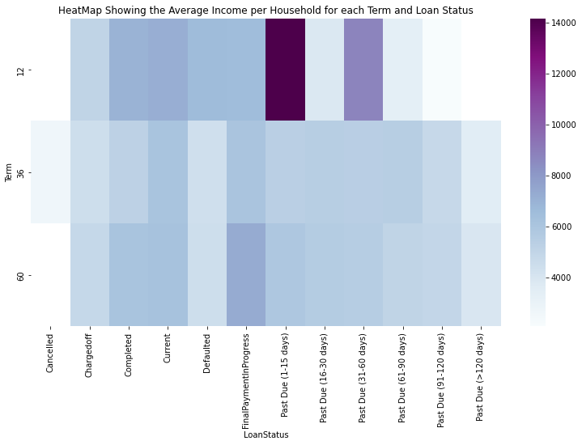